# Loan Eligibility (Project 2)

### You can view the dataset [here](https://www.kaggle.com/datasets/taweilo/loan-approval-classification-data).

# Introducing the Data

## Dataset Info

The Set contains 14 different columns of information, ranging from different categories and data types.

[output not shown]

[output not shown]

### What are we trying to answer

The Key Question we want to answer is

- **Can a Machine Learning Model predict Predict whether a loan applicant will be approved based on financial history.**

While also looking at:

- Does having a positive or negative credit history impact the likelihood of a loan?
- Which feature or features have the most influence on whether a loan is approved?

## Installing Libraries

```python
%pip install numpy pandas matplotlib seaborn imbalanced-learn
```

```python
import pandas as pd
import numpy as np
import matplotlib.pyplot as plt
import seaborn as sns
from sklearn.model_selection import train_test_split
from sklearn.ensemble import RandomForestClassifier
from sklearn.linear_model import LogisticRegression
from sklearn.metrics import accuracy_score, classification_report, confusion_matrix
import warnings
warnings.filterwarnings('ignore') # To make the cleanest Notebook stuff, removes pc errors and whatever.
```

## Reading and Looking into the Dataset

```python
# Reads "loan_data.csv" from local folder.
LoanDf = pd.read_csv('./loan_data.csv')
LoanDf.head(10)
```

|  | person_age | person_gender | person_education | person_income | person_emp_exp | person_home_ownership | loan_amnt | loan_intent | loan_int_rate | loan_percent_income | cb_person_cred_hist_length | credit_score | previous_loan_defaults_on_file | loan_status |
| --- | --- | --- | --- | --- | --- | --- | --- | --- | --- | --- | --- | --- | --- | --- |
| 0 | 22.0 | female | Master | 71948.0 | 0 | RENT | 35000.0 | PERSONAL | 16.02 | 0.49 | 3.0 | 561 | No | 1 |
| 1 | 21.0 | female | High School | 12282.0 | 0 | OWN | 1000.0 | EDUCATION | 11.14 | 0.08 | 2.0 | 504 | Yes | 0 |
| 2 | 25.0 | female | High School | 12438.0 | 3 | MORTGAGE | 5500.0 | MEDICAL | 12.87 | 0.44 | 3.0 | 635 | No | 1 |
| 3 | 23.0 | female | Bachelor | 79753.0 | 0 | RENT | 35000.0 | MEDICAL | 15.23 | 0.44 | 2.0 | 675 | No | 1 |
| 4 | 24.0 | male | Master | 66135.0 | 1 | RENT | 35000.0 | MEDICAL | 14.27 | 0.53 | 4.0 | 586 | No | 1 |
| 5 | 21.0 | female | High School | 12951.0 | 0 | OWN | 2500.0 | VENTURE | 7.14 | 0.19 | 2.0 | 532 | No | 1 |
| 6 | 26.0 | female | Bachelor | 93471.0 | 1 | RENT | 35000.0 | EDUCATION | 12.42 | 0.37 | 3.0 | 701 | No | 1 |
| 7 | 24.0 | female | High School | 95550.0 | 5 | RENT | 35000.0 | MEDICAL | 11.11 | 0.37 | 4.0 | 585 | No | 1 |
| 8 | 24.0 | female | Associate | 100684.0 | 3 | RENT | 35000.0 | PERSONAL | 8.90 | 0.35 | 2.0 | 544 | No | 1 |
| 9 | 21.0 | female | High School | 12739.0 | 0 | OWN | 1600.0 | VENTURE | 14.74 | 0.13 | 3.0 | 640 | No | 1 |

```python
print(LoanDf.shape)
```

```
(45000, 14)
```

#### 45,000 Entries Wow!

Here we can see what we are working with, with over 45,000 entries, and 14 columns spanning from different categories and values.

# Scrubbing and Cleaning the Data

Before we do any type of analysis, we need to make sure the data is good for us to use. First we want to make sure there aren't any null values or any sort of unnecessary information.

The first thing we do is drop any missing values from the dataset. This can lead to some major issues for us in the future when analyzing and can lead to inconsistencies with our model later.

```python
print(LoanDf.isnull().sum())
LoanDf.dropna(inplace=True)
LoanDf = LoanDf.drop_duplicates()
LoanDf.info()
```

```
person_age                        0
person_gender                     0
person_education                  0
person_income                     0
person_emp_exp                    0
person_home_ownership             0
loan_amnt                         0
loan_intent                       0
loan_int_rate                     0
loan_percent_income               0
cb_person_cred_hist_length        0
credit_score                      0
previous_loan_defaults_on_file    0
loan_status                       0
dtype: int64
<class 'pandas.core.frame.DataFrame'>
RangeIndex: 45000 entries, 0 to 44999
Data columns (total 14 columns):
 #   Column                          Non-Null Count  Dtype
---  ------                          --------------  -----
 0   person_age                      45000 non-null  float64
 1   person_gender                   45000 non-null  object
 2   person_education                45000 non-null  object
 3   person_income                   45000 non-null  float64
 4   person_emp_exp                  45000 non-null  int64
 5   person_home_ownership           45000 non-null  object
 6   loan_amnt                       45000 non-null  float64
 7   loan_intent                     45000 non-null  object
 8   loan_int_rate                   45000 non-null  float64
 9   loan_percent_income             45000 non-null  float64
 10  cb_person_cred_hist_length      45000 non-null  float64
 11  credit_score                    45000 non-null  int64
 12  previous_loan_defaults_on_file  45000 non-null  object
 13  loan_status                     45000 non-null  int64
dtypes: float64(6), int64(3), object(5)
memory usage: 4.8+ MB
```

## Checking how many loans were approved.

```
loan_status
0    35000
1    10000
Name: count, dtype: int64
```

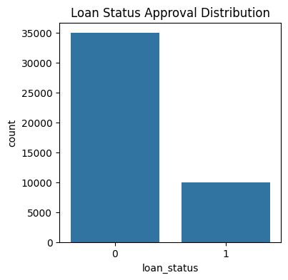

```python
print(LoanDf['loan_status'].value_counts())
plt.figure(figsize=(4,4))
sns.countplot(x=LoanDf["loan_status"])
plt.title("Loan Status Approval Distribution")
plt.show()
```

As we can see, within the dataset we have `35000` loans that were denied, and `10000` that were approved.

### Distrubution of Education Levels

The first area I want to look at is the education levels associated with the loan applications. As we can see majority of loan applications came from `High School` `Bachelor` and `Associate` where as `Master` and `Doctorate` are much lower.

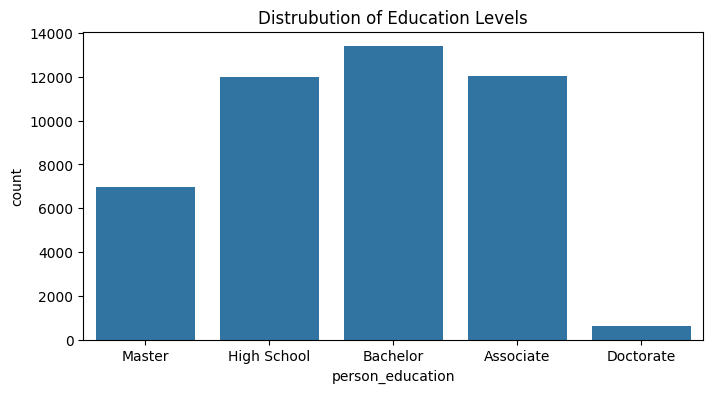

```python
plt.figure(figsize=(8,4))
sns.countplot(x=LoanDf["person_education"])
plt.title("Distrubution of Education Levels")
plt.show()
```

### Distrubution of Accepted Loans compared to Education Level

We can see that the dataset is pretty even in terms of being accepted or deneied within each of the education levels. The highest accepted percentage belongs to `Doctorate` with 22.87% although, the others are within a 1% range difference.

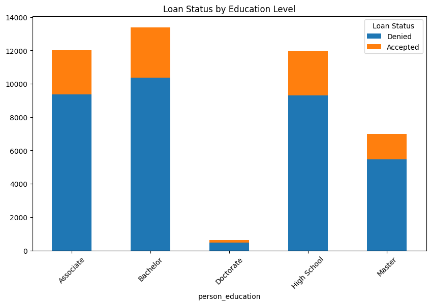

```
loan_status       Accepted_Percentage  Denied_Percentage
person_education
Associate                   22.031926          77.968074
Bachelor                    22.524069          77.475931
Doctorate                   22.866345          77.133655
High School                 22.310391          77.689609
Master                      21.762178          78.237822
```

```python
eduLoanStatus = LoanDf.groupby(['person_education', 'loan_status']).size().unstack()
eduLoanStatus.plot(kind='bar', stacked=True, figsize=(10, 6))
plt.title('Loan Status by Education Level')
plt.xticks(rotation=45)
plt.legend(title='Loan Status', labels=['Denied', 'Accepted'])
plt.show()

# Now get the percentages.
total = eduLoanStatus[0] + eduLoanStatus[1];
eduLoanStatus['Accepted_Percentage'] = (eduLoanStatus[1] / total) * 100
eduLoanStatus['Denied_Percentage'] = (eduLoanStatus[0] / total) * 100
print(eduLoanStatus[['Accepted_Percentage', 'Denied_Percentage']])
```

## Encoding the Data

We need to decide the data where the different categorys in values to help determine what can result to the final loan result.

To do this we convert the variables to a different format into different coluumns. For example, `person_gender` is registered as `male` or `female`, but we need to convert this to a value which we can understand within the code. This is true for other columns as well.

```python
categorical_columns = ['person_gender', 'person_education', 'person_home_ownership', 'loan_intent', 'previous_loan_defaults_on_file']
LoanDF_Encoded = pd.get_dummies(LoanDf, columns=categorical_columns, drop_first=True)
LoanDF_Encoded.head()
```

|  | person_age | person_income | person_emp_exp | loan_amnt | loan_int_rate | loan_percent_income | cb_person_cred_hist_length | credit_score | loan_status | person_gender_male | ... | person_education_Master | person_home_ownership_OTHER | person_home_ownership_OWN | person_home_ownership_RENT | loan_intent_EDUCATION | loan_intent_HOMEIMPROVEMENT | loan_intent_MEDICAL | loan_intent_PERSONAL | loan_intent_VENTURE | previous_loan_defaults_on_file_Yes |
| --- | --- | --- | --- | --- | --- | --- | --- | --- | --- | --- | --- | --- | --- | --- | --- | --- | --- | --- | --- | --- | --- |
| 0 | 22.0 | 71948.0 | 0 | 35000.0 | 16.02 | 0.49 | 3.0 | 561 | 1 | False | ... | True | False | False | True | False | False | False | True | False | False |
| 1 | 21.0 | 12282.0 | 0 | 1000.0 | 11.14 | 0.08 | 2.0 | 504 | 0 | False | ... | False | False | True | False | True | False | False | False | False | True |
| 2 | 25.0 | 12438.0 | 3 | 5500.0 | 12.87 | 0.44 | 3.0 | 635 | 1 | False | ... | False | False | False | False | False | False | True | False | False | False |
| 3 | 23.0 | 79753.0 | 0 | 35000.0 | 15.23 | 0.44 | 2.0 | 675 | 1 | False | ... | False | False | False | True | False | False | True | False | False | False |
| 4 | 24.0 | 66135.0 | 1 | 35000.0 | 14.27 | 0.53 | 4.0 | 586 | 1 | True | ... | True | False | False | True | False | False | True | False | False | False |

5 rows × 23 columns

### Heatmap

Lets first see if there are any patterns.

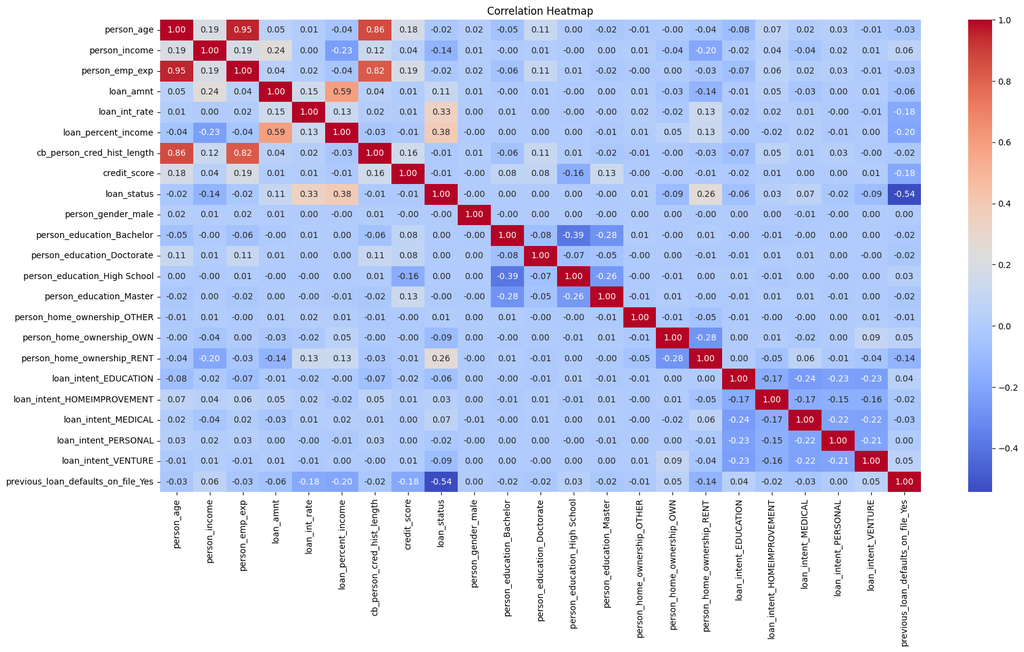

```python
plt.figure(figsize=(20, 10))
sns.heatmap(LoanDF_Encoded.corr(), annot=True, cmap='coolwarm', fmt='.2f')
plt.title('Correlation Heatmap')
plt.show()
```

# Splitting and Training the Dataset

To Split and train the data we want to include everything but the `loan_status` into the `x` and `y` will be the feature we will be testing for.

```python
x = LoanDF_Encoded.drop('loan_status', axis=1)
y = LoanDF_Encoded['loan_status']

x_train, x_test, y_train, y_test = train_test_split(x, y, test_size=.3, random_state=42);
```

# Lets Talk Modeling

For modeling our data we will be taking a look at 2 different algorithms we will be using for classification.

- Logistic Regression
  - A binary classification algorithm that is able to predict the probability of certain classes based on features.
- Random Forest
  - Builds many different decision trees and combines outputs. Trained on random subsets of the data, and then the final prediction is a majority rules scenario.

## Logistic Regression

For this section, Ill be using Logistic Regression to predict wheather an application is accepted or not. We will be using the Testing data set which will be 70% training and 30% testing.

```python
logreg = LogisticRegression()
logreg.fit(x_train, y_train)
y_pred_logreg = logreg.predict(x_test)
print("Logistic Regression Results:")
print(f"Accuracy score: {accuracy_score(y_test, y_pred_logreg)}")
```

```
Logistic Regression Results:
Accuracy score: 0.8418518518518519
```

### Classification Report & Confusion Matrix

The classificaition report showcases a 84% accuracy showing that it is majority of the time it is accurate, but still has room for error.

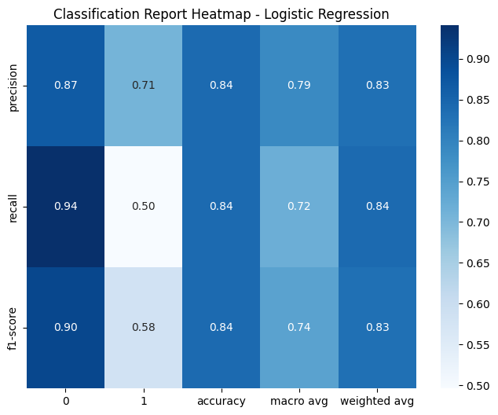

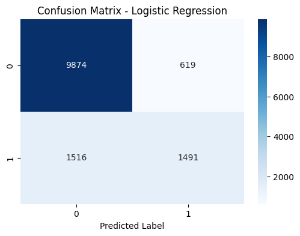

```python
report_df = pd.DataFrame(classification_report(y_test, y_pred_logreg, output_dict=True))

report_df = report_df.drop(['support', 'accuracy'], errors='ignore')
plt.figure(figsize=(8, 6))
sns.heatmap(report_df, annot=True, cmap="Blues", fmt=".2f")
plt.title("Classification Report Heatmap - Logistic Regression")
plt.show()

cm = confusion_matrix(y_test, y_pred_logreg)
plt.figure(figsize=(6, 4))
sns.heatmap(cm, annot=True, fmt='d', cmap='Blues')
plt.xlabel("Predicted Label")
plt.title("Confusion Matrix - Logistic Regression")
plt.show()
```

### Feature Importance

Here we can see that the most important feature was looking at if the applier had previous loan defaults. Unlike others `feature_importances_` doesnt seem to function here. So the graph is going to look different compared to one we see further below.

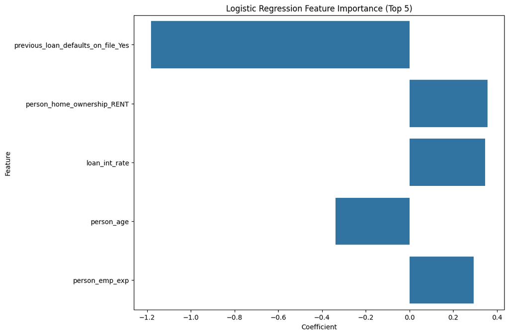

```python
feature_names = x_train.columns.tolist()
coefficients = logreg.coef_[0]
feature_importance = pd.DataFrame({ 'Feature': feature_names, 'Coefficient': coefficients, 'absolutevaluecoes': abs(coefficients) })
feature_importance = feature_importance.sort_values('absolutevaluecoes', ascending=False)
plt.figure(figsize=(10, 8))
sns.barplot( x='Coefficient', y='Feature', data=feature_importance.head(5),)
plt.title('Logistic Regression Feature Importance (Top 5)')
plt.ylabel('Feature')
plt.show()
```

## Random Forest

For this section, I implement a Random Forest Classifier.

```python
rf = RandomForestClassifier(n_estimators=100, random_state=42)
rf.fit(x_train, y_train)
y_pred_rf = rf.predict(x_test)
print("\nRandom Forest Results:")
print(f"Accuracy score: {accuracy_score(y_test, y_pred_rf)}")
```

```
Random Forest Results:
Accuracy score: 0.926074074074074
```

### Classification Report & Confusion Matrix

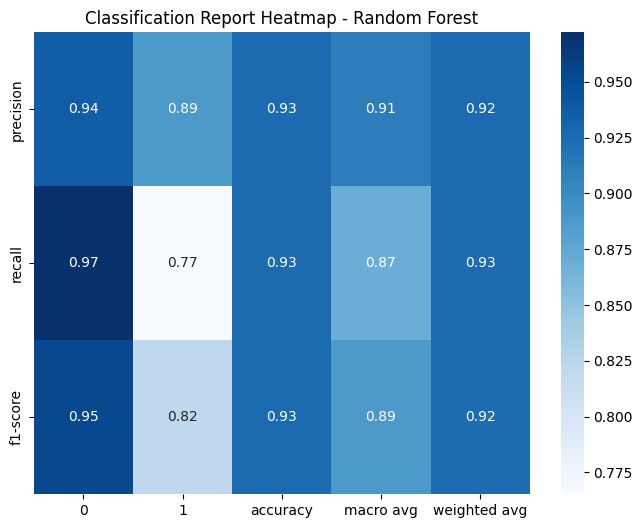

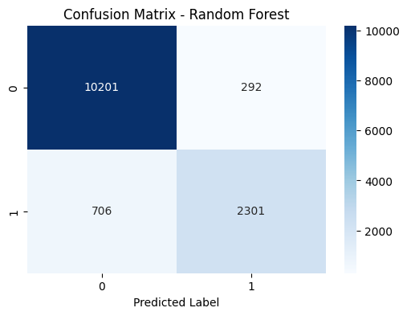

```python
report_rf = pd.DataFrame(classification_report(y_test, y_pred_rf, output_dict=True))

report_rf = report_rf.drop(['support', 'accuracy'], errors='ignore')
plt.figure(figsize=(8, 6))
sns.heatmap(report_rf, annot=True, cmap="Blues", fmt=".2f")
plt.title("Classification Report Heatmap - Random Forest")
plt.show()

cm = confusion_matrix(y_test, y_pred_rf)
plt.figure(figsize=(6, 4))
sns.heatmap(cm, annot=True, fmt='d', cmap='Blues')
plt.xlabel("Predicted Label")
plt.title("Confusion Matrix - Random Forest")
plt.show()
```

### Feature Importance

Here we can see that the most important feature was looking at if the applier had previous loan defaults. Here we can use the feature importances apart of the Random Forest Classifier.

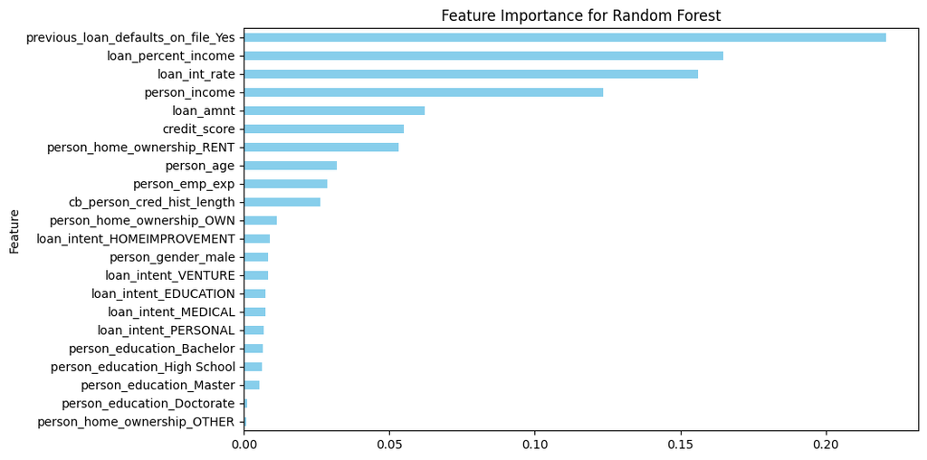

```python
fi = pd.Series(rf.feature_importances_, index=x.columns)
plt.figure(figsize=(10, 6))
fi.sort_values(ascending=True).plot(kind='barh', color='skyblue')
plt.ylabel('Feature')
plt.title("Feature Importance for Random Forest")
plt.show()
```

## Evaluation

Looking at the models, we can see that Random Forest provided the best accuracy score at 92%. Each model evaluated apon its classification report.

## Key Takeaways

- Previous Loans Play a Major Role
  - From the Feature Importance that we have done for both models it showcases that if an applicant had previously defaulted on a loan then it matters the most.
- Each Model has Mis-Classifications
  - In Each model, there are several inaccurate measures. There is not a 100% way to determine what allows you to receive an accepted application.

When taking a look at the initial question we set out to find `Can a Machine Learning Model predict Predict whether a loan applicant will be approved based on financial history.`. We can determine that while it is not 100%, it is close.

We can see that features did impact the loan approval process but, varies case by case. We also have to consider Human Interaction with the applicants. Different people handle loan applicants and sometimes make decisions on their own regardless of the details and information presented in front of them.

## Impacts

### Negative Impact

1. Potential Bias
   - The training data could contain biases as these loan approvals need to be done.
2. False Positives and Negatives
   - The model is not 100% accurate due to fluctuating factors, this can clead to incorrectly approving high risk applicatns or deny applications who are meant to recieve loans due to their history.
3. Humans
   - The model loses the humility of the selection in complex or edge cases where the answer may not be a clear definitive yes or no.

## References

1. Scikit Documentations | [Here](https://scikit-learn.org/stable/user_guide.html)
2. Loan Dataset | [Here](https://www.kaggle.com/datasets/taweilo/loan-approval-classification-data)

## Code

You can find the code [here](https://github.com/m1ke-dev/m1ke-dev.github.io/blob/main/project2/notebook.ipynb)